# Что влияет на посещение форума

## 1. Об отчете

### Переменные

- **Метрики форума**
  - *student_vis_mean* - среднее посещение форума студентами на курсе;
  - *student_vis_rate* - число студентов посетивших форум / число студентов на курсе;
  - *vis_b* - посещал форум или нет;
  - *vis_p* - количество посещенных страниц форума;
- **Тип курса.**
  - *spec_b* - индивидуальный курс или курс из специализации;
  - *is_prog_b* - есть задания по программированию в курсе или нет;
- **Тип задания** - бинарные переменные; сообщают есть ли такой тип задания на курсе;
  - *is_prog_b* - есть ли задание по программированию;
  - *is_math* - есть ли задание по математике;
  - *is_peer* - есть ли пир-ревью;

### Как создавались бинарные переменные типов заданий

- К сожалению, не всегда удается автоматически определить какие на курсе задания, а потому приходится использовать разнообразные признаки для их кодирования.
- *is_prog_b*
  - есть ли в таблице course_items.csv задания со словом “programming”;
  - есть ли в таблице assessment_questions.csv вопросы с типом 14 (codeExpression)
- *is_math*
  - есть ли задания в таблице assessment_math_expression_questions.csv;
  - есть ли в таблице peer_assignment_submission_schema_parts.csv слова “math”,“calculate”, “Рассчитайте”
- *is_peer*
  - есть ли в таблице ‘course_items.csv’ задание с типом 104 (peer-review);

### Исследовательские вопросы

1. Какая доля студентов посещает форум?
2. Сколько страниц форума в среднем посещают студенты?
3. Как отличается среднее посещение форума на курсах из специализаций и не из специализаций?
4. Как отличается среднее посещение форума на курсах с заданиями по программированию и без них?

### Содержание отчета

1. Вероятность посещения форума студентом.
2. Среднее количество посещенных страниц.
3. Влияние специализации на посещение форума.
4. Влияние специализации на количество посещенных страниц форума.
5. Влияние программирования на количество посещенных страниц форума.

### Описание баз данных и ее переменных

- Все рассматриваемые студенты закончили курс.
- Исключен преподавательский состав.
- Анализируем 60 курсов.
- 39 индивидуальных курса и 21 курсов из специализаций.
- В 15 курсах есть задания по программированию (см. переменную is_prog_b).

### Описание данных

```r
min(courses$student_n)
```

```
## [1] 11
```

```r
max(courses$student_n)
```

```
## [1] 6360
```

## 2. Сколько студентов посещает форум и сколько страниц они посещают

### 2.1 Вероятность посещения форума студентом

```r
m00 <- glm(factor(vis_b) ~ 1,
            family = binomial,
            students)
summary(m00)
```

```
##
## Call:
## glm(formula = factor(vis_b) ~ 1, family = binomial, data = students)
##
## Deviance Residuals:
##     Min       1Q   Median       3Q      Max
## -1.4874  -1.4874   0.8963   0.8963   0.8963
##
## Coefficients:
##             Estimate Std. Error z value Pr(>|z|)
## (Intercept) 0.704471   0.009514   74.05   <2e-16 ***
## ---
## Signif. codes:  0 '***' 0.001 '**' 0.01 '*' 0.05 '.' 0.1 ' ' 1
##
## (Dispersion parameter for binomial family taken to be 1)
##
##     Null deviance: 63353  on 49902  degrees of freedom
## Residual deviance: 63353  on 49902  degrees of freedom
## AIC: 63355
##
## Number of Fisher Scoring iterations: 4
```

```
## Generalized linear mixed model fit by maximum likelihood (Laplace
##   Approximation) [glmerMod]
##  Family: binomial  ( logit )
## Formula: factor(vis_b) ~ 1 + (1 | course_id)
##    Data: students
##
##      AIC      BIC   logLik deviance df.resid
##  51849.7  51867.4 -25922.9  51845.7    49901
##
## Scaled residuals:
##     Min      1Q  Median      3Q     Max
## -5.4394 -0.7913  0.2621  0.7334  1.6973
##
## Random effects:
##  Groups    Name        Variance Std.Dev.
##  course_id (Intercept) 1.723    1.312
## Number of obs: 49903, groups:  course_id, 60
##
## Fixed effects:
##             Estimate Std. Error z value Pr(>|z|)
## (Intercept)   1.0283     0.1765   5.826 5.68e-09 ***
## ---
## Signif. codes:  0 '***' 0.001 '**' 0.01 '*' 0.05 '.' 0.1 ' ' 1
```

```r
tab_model(m0)
```

|  | factor(vis b) |  |  |
| --- | --- | --- | --- |
| Predictors | Odds Ratios | CI | p |
| (Intercept) | 2.80 | 1.98 – 3.95 | **<0.001** |
| Random Effects |  |  |  |
| σ<sup>2</sup> | 3.29 |  |  |
| τ<sub>00</sub> <sub>course_id</sub> | 1.72 |  |  |
| ICC | 0.34 |  |  |
| N <sub>course_id</sub> | 60 |  |  |
| Observations | 49903 |  |  |
| Marginal R<sup>2</sup> / Conditional R<sup>2</sup> | 0.000 / 0.344 |  |  |

Выясним опорную переменную:

```r
contrasts(students$vis_b)
```

```
##   1
## 0 0
## 1 1
```

Результаты:

```
##
## 1) Вероятность посещения форума на среднем курсе равна 67% (через формулу вероятности) и (через обратный логит свободного члена модели m00) 67%.
```

```
##
## 2) Вероятность посещения форума на среднем курсе со стандратным отклонением свободного члена равна 74% (через обратный логит свободного члена модели m0).
```

```
## Эта вероятность будет колебаться между 43% и 91%  с одним стандартным отклонеием ниже и выше.
```

```
## SD =  0.79.
```

```
## AIC модели m00: 63355.
```

```
## AIC модели m0: 51850.
```

### 2.2 Количество страниц в среднем посещенных студентом

```r
m0 <- glmer.nb(vis_p ~ 1 + (1|course_id),
            students)
summary(m0)
```

```
## Generalized linear mixed model fit by maximum likelihood (Laplace
##   Approximation) [glmerMod]
##  Family: Negative Binomial(0.4361)  ( log )
## Formula: vis_p ~ 1 + (1 | course_id)
##    Data: students
##
##       AIC       BIC    logLik  deviance  df.resid
##  283366.2  283392.1 -141680.1  283360.2     42145
##
## Scaled residuals:
##     Min      1Q  Median      3Q     Max
## -0.6599 -0.5796 -0.3375  0.2864  4.5095
##
## Random effects:
##  Groups    Name        Variance Std.Dev.
##  course_id (Intercept) 10.72    3.275
## Number of obs: 42148, groups:  course_id, 60
##
## Fixed effects:
##             Estimate Std. Error z value Pr(>|z|)
## (Intercept)   1.2327     0.2581   4.776 1.79e-06 ***
## ---
## Signif. codes:  0 '***' 0.001 '**' 0.01 '*' 0.05 '.' 0.1 ' ' 1
```

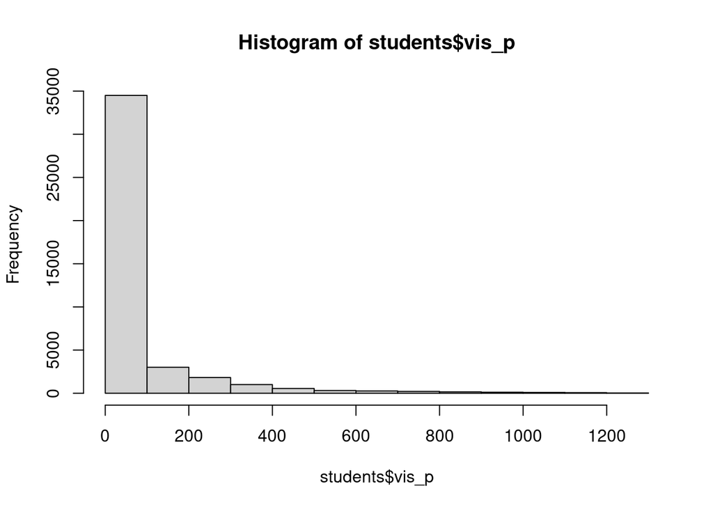

```
##
## Среднее посещение страниц форума равно 67 со стандартным отклонением 156
```

```
##
## Количество страниц, которые посещают студенты на форуме среднего курса со стандартным отклонением свободного члена: 3
```

```
## Это количество колеблется между: 0 и 91 страницами
```

```
## SD = 26.44.
```

```
## Необъясненная дисперсия (variance): 10.724367
```

```
## AIC модели m00: 63355.
```

```
## AIC модели m0: 283366.
```

```r
hist(students$vis_p)
```

## 3. Как на посещение форума влияет вхождение курса в специализацию

### 3.1 Влияние специализации на посещение форума студентом

```r
#contrasts(students$spec_b)
m0 <- glmer(vis_b ~ spec_b +(1|course_id),
            family = binomial,
            students)
summary(m0)
```

```
## Generalized linear mixed model fit by maximum likelihood (Laplace
##   Approximation) [glmerMod]
##  Family: binomial  ( logit )
## Formula: vis_b ~ spec_b + (1 | course_id)
##    Data: students
##
##      AIC      BIC   logLik deviance df.resid
##  51851.5  51878.0 -25922.8  51845.5    49900
##
## Scaled residuals:
##     Min      1Q  Median      3Q     Max
## -5.4198 -0.7913  0.2621  0.7334  1.6976
##
## Random effects:
##  Groups    Name        Variance Std.Dev.
##  course_id (Intercept) 1.72     1.312
## Number of obs: 49903, groups:  course_id, 60
##
## Fixed effects:
##             Estimate Std. Error z value Pr(>|z|)
## (Intercept)   1.0867     0.2197   4.947 7.52e-07 ***
## spec_bSPEC   -0.1633     0.3589  -0.455    0.649
## ---
## Signif. codes:  0 '***' 0.001 '**' 0.01 '*' 0.05 '.' 0.1 ' ' 1
##
## Correlation of Fixed Effects:
##            (Intr)
## spec_bSPEC -0.614
```

```
## Незначимо!
```

### 3.2 Влияние специализации на количество страниц посещенных студентом

```r
m0 <- glmer.nb(vis_p ~ spec_b +(1|course_id),
            students)
summary(m0)
```

```
## Generalized linear mixed model fit by maximum likelihood (Laplace
##   Approximation) [glmerMod]
##  Family: Negative Binomial(0.4361)  ( log )
## Formula: vis_p ~ spec_b + (1 | course_id)
##    Data: students
##
##       AIC       BIC    logLik  deviance  df.resid
##  283367.9  283402.5 -141680.0  283359.9     42144
##
## Scaled residuals:
##     Min      1Q  Median      3Q     Max
## -0.6599 -0.5797 -0.3375  0.2864  4.5091
##
## Random effects:
##  Groups    Name        Variance Std.Dev.
##  course_id (Intercept) 10.66    3.265
## Number of obs: 42148, groups:  course_id, 60
##
## Fixed effects:
##             Estimate Std. Error z value Pr(>|z|)
## (Intercept)   1.0772     0.4683   2.300   0.0214 *
## spec_bSPEC    0.4461     1.0786   0.414   0.6791
## ---
## Signif. codes:  0 '***' 0.001 '**' 0.01 '*' 0.05 '.' 0.1 ' ' 1
##
## Correlation of Fixed Effects:
##            (Intr)
## spec_bSPEC -0.670
```

```
## Незначимо!
```

## 4. Как на посещение форума влияет наличие на курсе заданий по программированию

### 4.1 Влияние программирования на посещение форума студентом

```r
m0 <- glmer(factor(vis_b) ~ is_prog_b + (1|course_id), family = "binomial",
            students)
summary(m0)
```

```
## Generalized linear mixed model fit by maximum likelihood (Laplace
##   Approximation) [glmerMod]
##  Family: binomial  ( logit )
## Formula: factor(vis_b) ~ is_prog_b + (1 | course_id)
##    Data: students
##
##      AIC      BIC   logLik deviance df.resid
##  51847.0  51873.5 -25920.5  51841.0    49900
##
## Scaled residuals:
##     Min      1Q  Median      3Q     Max
## -5.3524 -0.7912  0.2620  0.7332  1.6974
##
## Random effects:
##  Groups    Name        Variance Std.Dev.
##  course_id (Intercept) 1.561    1.25
## Number of obs: 49903, groups:  course_id, 60
##
## Fixed effects:
##             Estimate Std. Error z value Pr(>|z|)
## (Intercept)   0.8028     0.1893   4.241 2.23e-05 ***
## is_prog_b     0.8511     0.3653   2.330   0.0198 *
## ---
## Signif. codes:  0 '***' 0.001 '**' 0.01 '*' 0.05 '.' 0.1 ' ' 1
##
## Correlation of Fixed Effects:
##           (Intr)
## is_prog_b -0.484
```

[output not shown]

### 4.2 Влияние программирования на количество страниц посещенных студентом

```r
m0 <- glmer.nb(vis_p ~ is_prog_b + (1|course_id),
            students)
summary(m0)
```

```
## Generalized linear mixed model fit by maximum likelihood (Laplace
##   Approximation) [glmerMod]
##  Family: Negative Binomial(0.4361)  ( log )
## Formula: vis_p ~ is_prog_b + (1 | course_id)
##    Data: students
##
##       AIC       BIC    logLik  deviance  df.resid
##  283358.6  283393.2 -141675.3  283350.6     42144
##
## Scaled residuals:
##     Min      1Q  Median      3Q     Max
## -0.6599 -0.5797 -0.3375  0.2866  4.5059
##
## Random effects:
##  Groups    Name        Variance Std.Dev.
##  course_id (Intercept) 8.92     2.987
## Number of obs: 42148, groups:  course_id, 60
##
## Fixed effects:
##             Estimate Std. Error z value Pr(>|z|)
## (Intercept)   0.5261     0.3060   1.719   0.0856 .
## is_prog_b     2.8747     0.4305   6.677 2.44e-11 ***
## ---
## Signif. codes:  0 '***' 0.001 '**' 0.01 '*' 0.05 '.' 0.1 ' ' 1
##
## Correlation of Fixed Effects:
##           (Intr)
## is_prog_b -0.453
```

[output not shown]

```
## Ожидаемое количество страниц на форуме, которые студенты посещают на курсе с программированием: 29.99.
```

```
## Ожидаемое количество страниц на форуме на курсах с программированию выше количества страниц на курсах без программирования в 17.72 раз.
```

```
## AIC модели без предиктора - 283366.19 и AIC с предиктором - 283358.59
```

```
## SD = 19.82, CI = 1.51-594.27.
```

```
## Необъясненная дисперсия модели без предиктора - 10.72 и необъясненная дисперсия с предиктором - 8.92
```

#### Визуализация

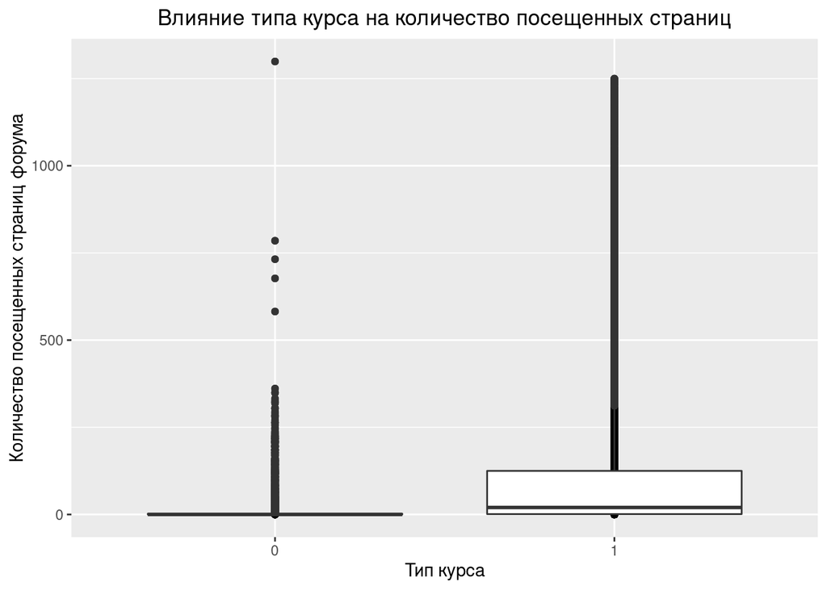

```r
students %>%
  ggplot(aes(x = factor(is_prog_b), y = vis_p)) + geom_point() + geom_boxplot() + ggtitle("Влияние типа курса на количество посещенных страниц") + labs(x="Тип курса", y = "Количество посещенных страниц форума") +  theme(plot.title = element_text(hjust = 0.5))
```

## 5. Как на среднее посещение форума на курсе влияет тип заданий на курсе

### 5.1 Описательная статистика

```
## Распределение курсов по типу заданий:
```

[output not shown]

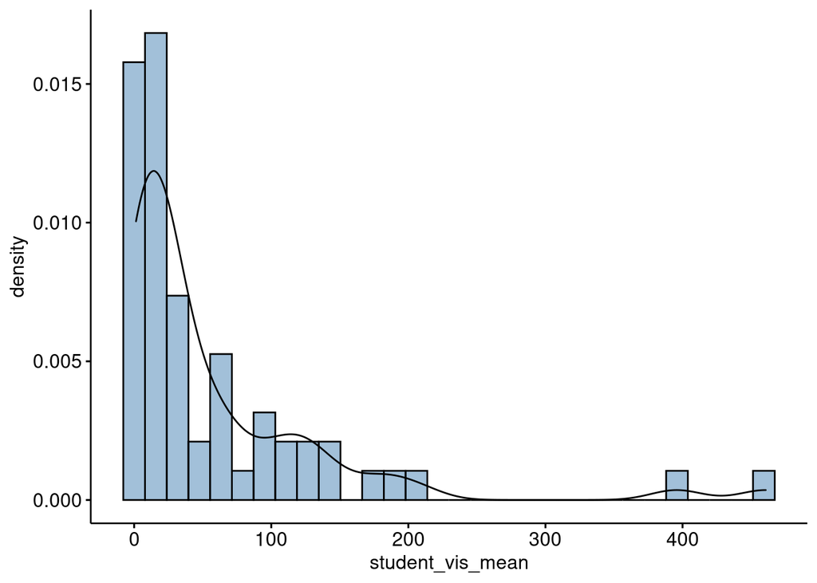

```r
gghistogram(courses, x = "student_vis_mean", y = "..density..",
            fill = "steelblue",bins = 30, add_density = TRUE)
```

```r
shapiro.test(courses$student_vis_mean)
```

```
##
##  Shapiro-Wilk normality test
##
## data:  courses$student_vis_mean
## W = 0.64705, p-value = 9.601e-11
```

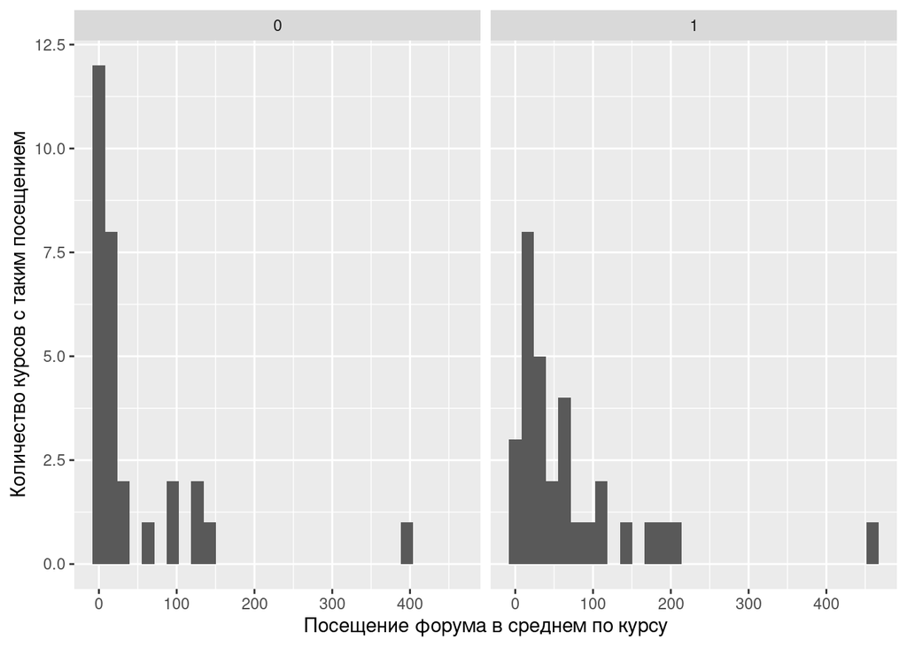

```r
courses %>%
  ggplot(aes(x = student_vis_mean)) + geom_histogram() + facet_wrap(~is_peer_b, labeller = labeller(yes = "1", no = "0")) + labs(x = "Посещение форума в среднем по курсу", y = "Количество курсов с таким посещением")
```

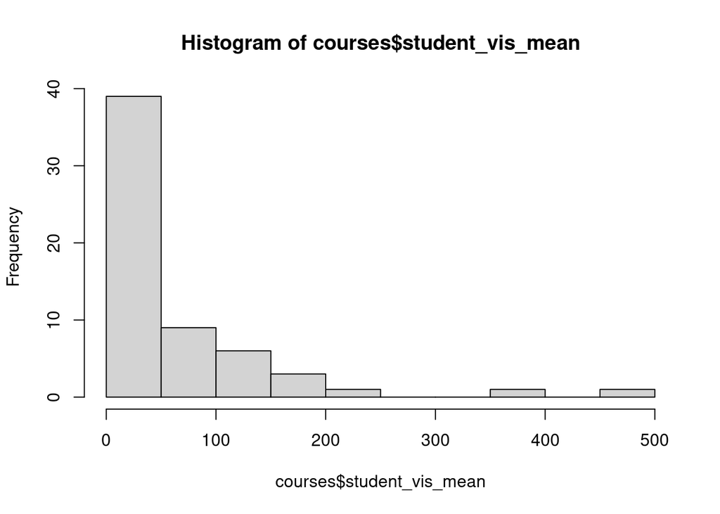

```r
hist(courses$student_vis_mean)
```

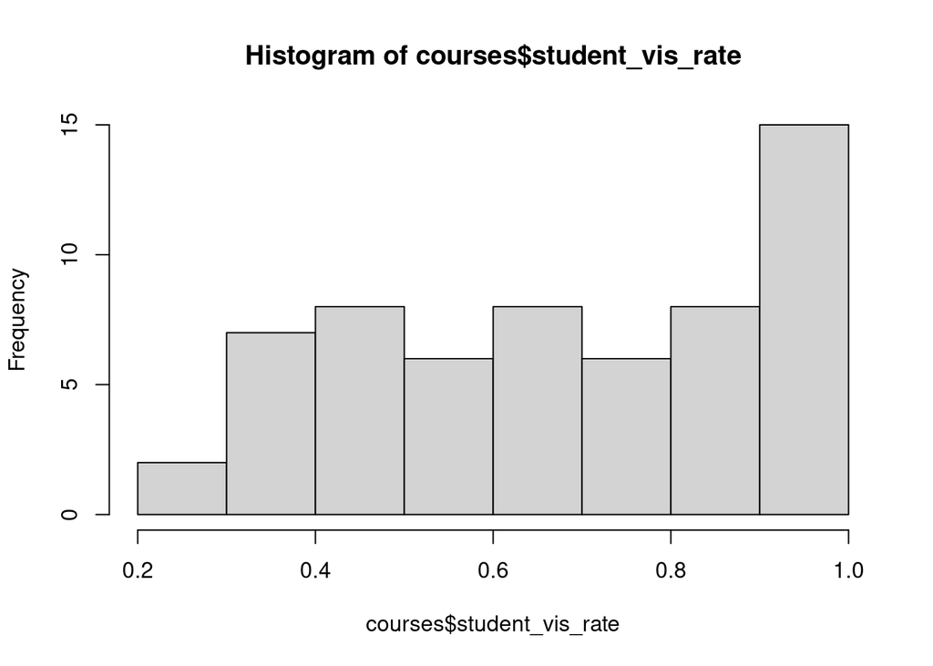

```r
hist(courses$student_vis_rate)
```

### 5.2 Mann-Whitney U tests в виде расчетов и с силой эффекта

#### Во всех трех случаях есть значимая разница в среднем посещении форума между курсами с разными типами заданий

```
##
##  Wilcoxon rank sum exact test
##
## data:  student_vis_mean by is_prog_b
## W = 151, p-value = 0.001073
## alternative hypothesis: true location shift is not equal to 0
```

```
## # A tibble: 1 x 7
##   .y.              group1 group2 effsize    n1    n2 magnitude
## * <chr>            <chr>  <chr>    <dbl> <int> <int> <ord>
## 1 student_vis_mean 0      1        0.411    45    15 moderate
```

```
## # A tibble: 2 x 2
##   is_prog_b median
##   <fct>      <dbl>
## 1 0           17.4
## 2 1           97.2
```

```
##
##  Wilcoxon rank sum exact test
##
## data:  student_vis_mean by is_math_b
## W = 237, p-value = 0.003706
## alternative hypothesis: true location shift is not equal to 0
```

```
## # A tibble: 1 x 7
##   .y.              group1 group2 effsize    n1    n2 magnitude
## * <chr>            <chr>  <chr>    <dbl> <int> <int> <ord>
## 1 student_vis_mean 0      1        0.370    37    23 moderate
```

```
##
##  Wilcoxon rank sum exact test
##
## data:  student_vis_mean by is_peer_b
## W = 264, p-value = 0.005605
## alternative hypothesis: true location shift is not equal to 0
```

```
## # A tibble: 1 x 7
##   .y.              group1 group2 effsize    n1    n2 magnitude
## * <chr>            <chr>  <chr>    <dbl> <int> <int> <ord>
## 1 student_vis_mean 0      1        0.354    29    31 moderate
```

```
##
##  Wilcoxon rank sum exact test
##
## data:  student_vis_mean by spec_b
## W = 308, p-value = 0.1181
## alternative hypothesis: true location shift is not equal to 0
```

```
## # A tibble: 1 x 7
##   .y.              group1 group2 effsize    n1    n2 magnitude
## * <chr>            <chr>  <chr>    <dbl> <int> <int> <ord>
## 1 student_vis_mean IND    SPEC     0.203    39    21 small
```

```
## # A tibble: 2 x 2
##   spec_b median
##   <chr>   <dbl>
## 1 IND      19.5
## 2 SPEC     35.9
```

### 5.3 Mann-Whitney U tests в виде графиков

#### На графиках указаны статистики теста и значимость различий между курсами с разными типами заданий

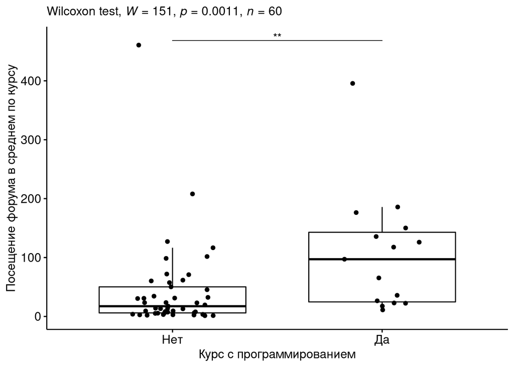

```r
stat.test <- courses %>%
  wilcox_test(student_vis_mean ~ is_prog_b) %>%
  add_significance()
bxp <- ggboxplot(
  courses, x = "is_prog_b", y = "student_vis_mean",
  ylab = "Посещение форума в среднем по курсу", xlab = "Курс с программированием", add = "jitter") +
scale_x_discrete(labels=c("Нет","Да"))
stat.test <- stat.test %>% add_xy_position(x = "group")
bxp +
  stat_pvalue_manual(stat.test, tip.length = 0) +
  labs(subtitle = get_test_label(stat.test, detailed = TRUE))
```

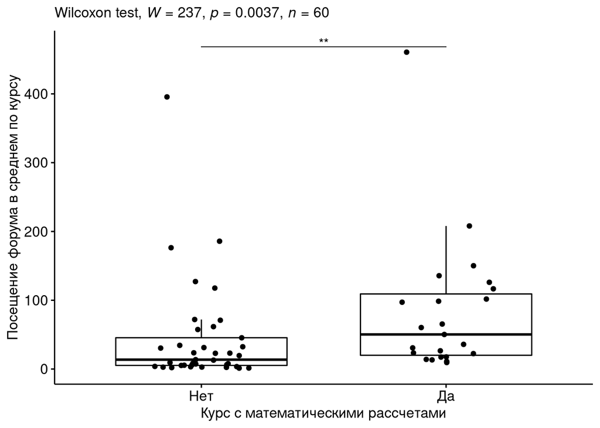

```r
stat.test <- courses %>%
  wilcox_test(student_vis_mean ~ is_math_b) %>%
  add_significance()
bxp <- ggboxplot(
  courses, x = "is_math_b", y = "student_vis_mean",
  ylab = "Посещение форума в среднем по курсу", xlab = "Курс с математическими рассчетами", add = "jitter") +
scale_x_discrete(labels=c("Нет","Да"))
stat.test <- stat.test %>% add_xy_position(x = "group")
bxp +
  stat_pvalue_manual(stat.test, tip.length = 0) +
  labs(subtitle = get_test_label(stat.test, detailed = TRUE))
```

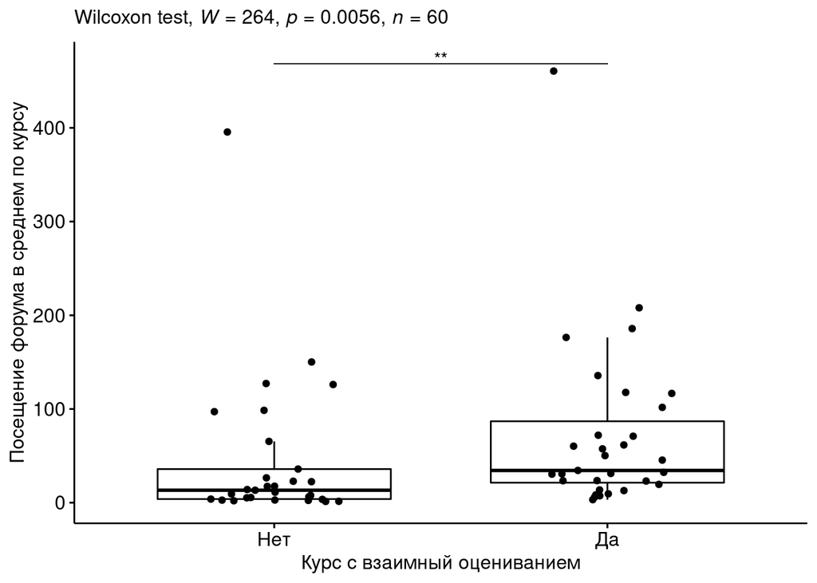

```r
stat.test <- courses %>%
  wilcox_test(student_vis_mean ~ is_peer_b) %>%
  add_significance()
bxp <- ggboxplot(
  courses, x = "is_peer_b", y = "student_vis_mean",
  ylab = "Посещение форума в среднем по курсу", xlab = "Курс с взаимный оцениванием", add = "jitter") +
scale_x_discrete(labels=c("Нет","Да"))
stat.test <- stat.test %>% add_xy_position(x = "group")
bxp +
  stat_pvalue_manual(stat.test, tip.length = 0) +
  labs(subtitle = get_test_label(stat.test, detailed = TRUE))
```

[figure not shown]

```r
stat.test <- courses %>%
  wilcox_test(student_vis_mean ~ spec_b) %>%
  add_significance()
bxp <- ggboxplot(
  courses, x = "spec_b", y = "student_vis_mean",
  ylab = "Посещение форума в среднем по курсу", xlab = "Курс входит в специализацию", add = "jitter") +
scale_x_discrete(labels=c("Нет","Да"))
stat.test <- stat.test %>% add_xy_position(x = "group")
bxp +
  stat_pvalue_manual(stat.test, tip.length = 0) +
  labs(subtitle = get_test_label(stat.test, detailed = TRUE))
```

### 5.4 Доля посещений

```r
wt1 <- wilcox.test(student_vis_rate ~ is_prog_b, courses, exact=FALSE)
w1 <- courses %>% wilcox_effsize(student_vis_rate ~ is_prog_b)
wt1
```

```
##
##  Wilcoxon rank sum test with continuity correction
##
## data:  student_vis_rate by is_prog_b
## W = 228, p-value = 0.06258
## alternative hypothesis: true location shift is not equal to 0
```

```r
w1$effsize
```

```
## Effect size (r)
##       0.2415084
```

```r
wt1 <- wilcox.test(student_vis_rate ~ is_math_b, courses, exact=FALSE)
w1 <- courses %>% wilcox_effsize(student_vis_rate ~ is_math_b)
wt1
```

```
##
##  Wilcoxon rank sum test with continuity correction
##
## data:  student_vis_rate by is_math_b
## W = 368.5, p-value = 0.39
## alternative hypothesis: true location shift is not equal to 0
```

```r
w1$effsize
```

```
## Effect size (r)
##       0.1119645
```

```r
wt1 <- wilcox.test(student_vis_rate ~ is_peer_b, courses, exact=FALSE)
w1 <- courses %>% wilcox_effsize(student_vis_rate ~ is_peer_b)
wt1
```

```
##
##  Wilcoxon rank sum test with continuity correction
##
## data:  student_vis_rate by is_peer_b
## W = 213, p-value = 0.0004765
## alternative hypothesis: true location shift is not equal to 0
```

```r
w1$effsize
```

```
## Effect size (r)
##       0.4519823
```

```r
wt1 <- wilcox.test(student_vis_rate ~ spec_b, courses, exact=FALSE)
w1 <- courses %>% wilcox_effsize(student_vis_rate ~ spec_b)
wt1
```

```
##
##  Wilcoxon rank sum test with continuity correction
##
## data:  student_vis_rate by spec_b
## W = 439, p-value = 0.6529
## alternative hypothesis: true location shift is not equal to 0
```

```r
w1$effsize
```

```
## Effect size (r)
##      0.05906771
```